# UE20CS312 - Data Analytics Worksheet 2c - Logistic Regression

Gaurav Dept. of CSE - PES1UG20CS150

2022-09-19

```r
library(tidyverse)
library(InformationValue)
char_preds <- read.csv('got_characters.csv')
head(char_preds,10)
```

```
##    X S.No actual                 name                title male  culture
## 1  0    1      0 Viserys II Targaryen                         1
## 2  1    2      1          Walder Frey Lord of the Crossing    1 Rivermen
## 3  2    3      1         Addison Hill                  Ser    1
## 4  3    4      0          Aemma Arryn                Queen    0
## 5  4    5      1       Sylva Santagar           Greenstone    0  Dornish
## 6  5    6      1     Tommen Baratheon                         1
## 7  6    7      0     Valarr Targaryen     Hand of the King    1 Valyrian
## 8  7    8      0  Viserys I Targaryen                         1
## 9  8    9      0              Wilbert                  Ser    1
## 10 9   10      1       Wilbert Osgrey                  Ser    1
##    dateOfBirth             mother           father               heir
## 1           NA Rhaenyra Targaryen Daemon Targaryen Aegon IV Targaryen
## 2          208
## 3           NA
```

[output cut: 40 more lines]

### Problem 1 (1 point)

How many characters from the SoIaF world does this dataset contain information on? Calculate the percentage of missing data for each column of the dataset and print them out in descending order as a dataframe.

*Hint:* Make sure to capture data from both missing values in numeric fields and empty strings in descriptive fields. Convert all missing placeholders to type NA.

```r
sprintf("The no. of characters listed in the data = %d", nrow(char_preds))
```

```
## [1] "The no. of characters listed in the data = 1946"
```

```r
#changing all the missing or empty values to NA
char_preds[char_preds == "" | char_preds == " "] <- NA
head(char_preds,10)
```

```
##    X S.No actual                 name                title male  culture
## 1  0    1      0 Viserys II Targaryen                 <NA>    1     <NA>
## 2  1    2      1          Walder Frey Lord of the Crossing    1 Rivermen
## 3  2    3      1         Addison Hill                  Ser    1     <NA>
## 4  3    4      0          Aemma Arryn                Queen    0     <NA>
## 5  4    5      1       Sylva Santagar           Greenstone    0  Dornish
## 6  5    6      1     Tommen Baratheon                 <NA>    1     <NA>
## 7  6    7      0     Valarr Targaryen     Hand of the King    1 Valyrian
## 8  7    8      0  Viserys I Targaryen                 <NA>    1     <NA>
## 9  8    9      0              Wilbert                  Ser    1     <NA>
## 10 9   10      1       Wilbert Osgrey                  Ser    1     <NA>
##    dateOfBirth             mother           father               heir
## 1           NA Rhaenyra Targaryen Daemon Targaryen Aegon IV Targaryen
## 2          208               <NA>             <NA>               <NA>
## 3           NA               <NA>             <NA>               <NA>
```

[output cut: 40 more lines]

#as we can see this dataframe created with the null value percentages is as shown above now this should be arranged in decreasing order

```r
df <- data.frame(colSums(is.na(char_preds)) / nrow(char_preds) * 100)
colnames(df) <- c('percent_Missing') #rename cols with appropriate headers
df$Columns <- rownames(df)
rownames(df) <- NULL
df
```

```
##    percent_Missing           Columns
## 1          0.00000                 X
## 2          0.00000              S.No
## 3          0.00000            actual
## 4          0.00000              name
## 5         51.79856             title
## 6          0.00000              male
## 7         65.21069           culture
## 8         77.74923       dateOfBirth
## 9         98.92086            mother
## 10        98.66393            father
## 11        98.81809              heir
## 12        21.94245             house
## 13        85.81706            spouse
## 14         0.00000             book1
## 15         0.00000             book2
## 16         0.00000             book3
## 17         0.00000             book4
## 18         0.00000             book5
## 19        98.92086     isAliveMother
## 20        98.66393     isAliveFather
## 21        98.81809       isAliveHeir
## 22        85.81706     isAliveSpouse
## 23         0.00000         isMarried
## 24         0.00000           isNoble
## 25        77.74923               age
## 26         0.00000  numDeadRelations
## 27         0.00000 boolDeadRelations
## 28         0.00000         isPopular
## 29         0.00000        popularity
```

```r
new_df <- df[order(df$percent_Missing, decreasing = TRUE),]
rownames(new_df) <- NULL
new_df
```

```
##    percent_Missing           Columns
## 1         98.92086            mother
## 2         98.92086     isAliveMother
## 3         98.81809              heir
## 4         98.81809       isAliveHeir
## 5         98.66393            father
## 6         98.66393     isAliveFather
## 7         85.81706            spouse
## 8         85.81706     isAliveSpouse
## 9         77.74923       dateOfBirth
## 10        77.74923               age
## 11        65.21069           culture
## 12        51.79856             title
## 13        21.94245             house
## 14         0.00000                 X
## 15         0.00000              S.No
## 16         0.00000            actual
## 17         0.00000              name
## 18         0.00000              male
## 19         0.00000             book1
## 20         0.00000             book2
## 21         0.00000             book3
## 22         0.00000             book4
## 23         0.00000             book5
## 24         0.00000         isMarried
## 25         0.00000           isNoble
## 26         0.00000  numDeadRelations
## 27         0.00000 boolDeadRelations
## 28         0.00000         isPopular
## 29         0.00000        popularity
```

### Problem 2 (2 points)

#### Step 1

What are the inferences you can draw from the output dataframe of the previous problem? How can we handle columns with extremely high proportions of missing data before moving on?

*Hint:* Does missing data in a column tell you something about the target variable (`actual`)? If not, set a missing percentage threshold of 80%, deeming the column as having insufficient data, and drop the column.

```r
cor.test(char_preds$actual,char_preds$isAliveMother)
```

```
##
##  Pearson's product-moment correlation
##
## data:  char_preds$actual and char_preds$isAliveMother
## t = -0.18775, df = 19, p-value = 0.8531
## alternative hypothesis: true correlation is not equal to 0
## 95 percent confidence interval:
##  -0.4660620  0.3960103
## sample estimates:
##         cor
## -0.04303315
```

```r
print("===================================================================================================")
```

```
## [1] "==================================================================================================="
```

```r
cor.test(char_preds$actual,char_preds$isAliveFather)
```

```
##
##  Pearson's product-moment correlation
##
## data:  char_preds$actual and char_preds$isAliveFather
## t = 0.97915, df = 24, p-value = 0.3373
## alternative hypothesis: true correlation is not equal to 0
## 95 percent confidence interval:
##  -0.2070815  0.5421823
## sample estimates:
##       cor
## 0.1959916
```

```r
print("===================================================================================================")
```

```
## [1] "==================================================================================================="
```

```r
cor.test(char_preds$actual,char_preds$isAliveSpouse)
```

```
##
##  Pearson's product-moment correlation
##
## data:  char_preds$actual and char_preds$isAliveSpouse
## t = 2.9296, df = 274, p-value = 0.00368
## alternative hypothesis: true correlation is not equal to 0
## 95 percent confidence interval:
##  0.05738708 0.28645037
## sample estimates:
##       cor
## 0.1742754
```

```r
print("===================================================================================================")
```

```
## [1] "==================================================================================================="
```

```r
cor.test(char_preds$actual,char_preds$isAliveHeir)
```

```
##
##  Pearson's product-moment correlation
##
## data:  char_preds$actual and char_preds$isAliveHeir
## t = 1.9111, df = 21, p-value = 0.06974
## alternative hypothesis: true correlation is not equal to 0
## 95 percent confidence interval:
##  -0.03245048  0.68795387
## sample estimates:
##       cor
## 0.3849002
```

```r
print("===================================================================================================")
```

```
## [1] "==================================================================================================="
```

```r
removeable <- new_df[new_df$percent_Missing > 80,'Columns']
removeable
```

```
## [1] "mother"        "isAliveMother" "heir"          "isAliveHeir"
## [5] "father"        "isAliveFather" "spouse"        "isAliveSpouse"
```

```r
char_preds <- char_preds[!names(char_preds) %in% removeable]
head(char_preds)
```

```
##   X S.No actual                 name                title male  culture
## 1 0    1      0 Viserys II Targaryen                 <NA>    1     <NA>
## 2 1    2      1          Walder Frey Lord of the Crossing    1 Rivermen
## 3 2    3      1         Addison Hill                  Ser    1     <NA>
## 4 3    4      0          Aemma Arryn                Queen    0     <NA>
## 5 4    5      1       Sylva Santagar           Greenstone    0  Dornish
## 6 5    6      1     Tommen Baratheon                 <NA>    1     <NA>
##   dateOfBirth          house book1 book2 book3 book4 book5 isMarried isNoble
## 1          NA           <NA>     0     0     0     0     0         0       0
## 2         208     House Frey     1     1     1     1     1         1       1
## 3          NA    House Swyft     0     0     0     1     0         0       1
## 4          82    House Arryn     0     0     0     0     0         1       1
## 5         276 House Santagar     0     0     0     1     0         1       1
## 6          NA           <NA>     0     0     0     0     0         0       0
##   age numDeadRelations boolDeadRelations isPopular popularity
## 1  NA               11                 1         1 0.60535117
## 2  97                1                 1         1 0.89632107
## 3  NA                0                 0         0 0.26755853
## 4  23                0                 0         0 0.18394649
## 5  29                0                 0         0 0.04347826
## 6  NA                5                 1         1 1.00000000
```

#### Step 2

Impute missing data in the remaining numeric features with a reasonable statistic. Make sure you observe the distribution of the data in the columns to pick out a reasonable statistic. For categorical variables, convert the columns to numeric features. *Hint: Use the `unclass` function and impute missing categorical feature values with a `-1`.*

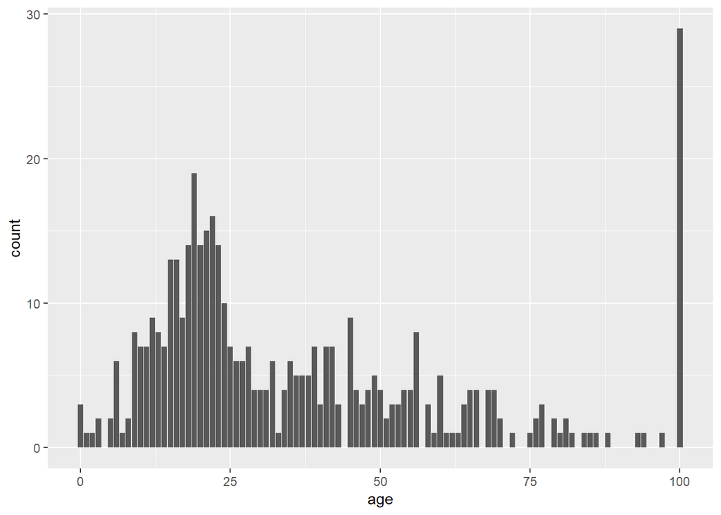

```r
ggplot(char_preds, aes(x=age)) + geom_bar()
```

```r
char_preds<-char_preds %>% mutate(age = ifelse(is.na(age),median(age, na.rm = T),age))
char_preds
```

```
##         X S.No actual                                       name
## 1       0    1      0                       Viserys II Targaryen
## 2       1    2      1                                Walder Frey
## 3       2    3      1                               Addison Hill
## 4       3    4      0                                Aemma Arryn
## 5       4    5      1                             Sylva Santagar
## 6       5    6      1                           Tommen Baratheon
## 7       6    7      0                           Valarr Targaryen
## 8       7    8      0                        Viserys I Targaryen
## 9       8    9      0                                    Wilbert
## 10      9   10      1                             Wilbert Osgrey
## 11     10   11      0                                       Will
## 12     11   12      1                              Will (orphan)
## 13     12   13      1                              Will (squire)
## 14     13   14      1                           Will (Standfast)
```

[output cut: 11667 more lines]

```r
char_preds<-char_preds %>% mutate(dateOfBirth = ifelse(is.na(dateOfBirth),median(dateOfBirth, na.rm = T),dateOfBirth))
char_preds
```

```
##         X S.No actual                                       name
## 1       0    1      0                       Viserys II Targaryen
## 2       1    2      1                                Walder Frey
## 3       2    3      1                               Addison Hill
## 4       3    4      0                                Aemma Arryn
## 5       4    5      1                             Sylva Santagar
## 6       5    6      1                           Tommen Baratheon
## 7       6    7      0                           Valarr Targaryen
## 8       7    8      0                        Viserys I Targaryen
## 9       8    9      0                                    Wilbert
## 10      9   10      1                             Wilbert Osgrey
## 11     10   11      0                                       Will
## 12     11   12      1                              Will (orphan)
## 13     12   13      1                              Will (squire)
## 14     13   14      1                           Will (Standfast)
```

[output cut: 11667 more lines]

```r
char_categorical <- c("culture","title","house")
char_preds[, char_categorical] <- lapply(char_preds[, char_categorical], as.factor)
char_preds[, char_categorical] <- sapply(char_preds[, char_categorical], unclass)

# Replace missing with -1
char_preds[is.na(char_preds)] = -1

head(char_preds,10)
```

```
##    X S.No actual                 name title male culture dateOfBirth house
## 1  0    1      0 Viserys II Targaryen    -1    1      -1         268    -1
## 2  1    2      1          Walder Frey   146    1      30         208   118
## 3  2    3      1         Addison Hill   222    1      -1         268   273
## 4  3    4      0          Aemma Arryn   198    0      -1          82    25
## 5  4    5      1       Sylva Santagar    71    0       7         276   246
## 6  5    6      1     Tommen Baratheon    -1    1      -1         268    -1
## 7  6    7      0     Valarr Targaryen    75    1      38         183   275
## 8  7    8      0  Viserys I Targaryen    -1    1      -1         268    -1
## 9  8    9      0              Wilbert   222    1      -1         268    -1
## 10 9   10      1       Wilbert Osgrey   222    1      -1         268   216
##    book1 book2 book3 book4 book5 isMarried isNoble age numDeadRelations
## 1      0     0     0     0     0         0       0  27               11
## 2      1     1     1     1     1         1       1  97                1
## 3      0     0     0     1     0         0       1  27                0
```

[output cut: 18 more lines]

### Problem 3 (2 points)

#### Step 1: Check for Class Bias

Ideally, the proportion of both classes of the target variable should be the same. Is this so in the case of the target variable in this dataset?

```r
table(char_preds$actual)
```

```
##
##    0    1
##  495 1451
```

#### Step 2: Create Training and Test Samples

Perform undersampling in case of a class bias in the dataset. Create train and test splits.

*Hint: To create the training sample set, sample 70% of the class with lesser rows and sample the same number from the other class. Use the remaining rows from both classes to create the test split.*

```r
input_ones <- char_preds[which(char_preds$actual == 1), ]
input_zeros <- char_preds[which(char_preds$actual == 0), ]  # all 0's
set.seed(100)

# Sample from all alive characters
input_ones_training_rows <- sample(1:nrow(input_ones), 0.7*nrow(input_zeros))
# Sample from all dead characters
input_zeros_training_rows <- sample(1:nrow(input_zeros), 0.7*nrow(input_zeros))
```

```r
training_ones <- input_ones[input_ones_training_rows, ]
training_zeros <- input_zeros[input_zeros_training_rows, ]

# Row bind both class dataframes
trainingData <- rbind(training_ones, training_zeros)
# Shuffle rows
trainingData <- trainingData[sample(1:nrow(trainingData)), ]

head(trainingData,10)
```

```
##         X S.No actual                                name title male culture
## 635   634  635      0 Jeyne Westerling (wife of Maegor I)   199    0      -1
## 574   573  574      0                   Hamish the Harper    -1    0      -1
## 1912 1911 1912      0                        Waymar Royce   222    1      37
## 1300 1299 1300      0                        Ralf Kenning    27    1      12
## 604   603  604      0                      Hendry Bracken    -1    0      -1
## 1201 1200 1201      1                        Lyra Mormont    -1    0      22
## 278   277  278      0                        Addam Osgrey    -1    1      -1
## 1474 1473 1474      1                          Bloodbeard    -1    0      -1
## 318   317  318      0                     Andrey Charlton   222    1      -1
## 1603 1602 1603      0                     Qhorin Halfhand    -1    1      -1
##      dateOfBirth house book1 book2 book3 book4 book5 isMarried isNoble age
## 635           27   308     0     0     1     0     0         1       1  20
## 574          268    -1     0     0     1     1     1         0       0  27
## 1912         278   240     1     1     1     1     0         0       1  19
```

[output cut: 18 more lines]

```r
test_ones <- input_ones[-input_ones_training_rows, ]
test_zeros <- input_zeros[-input_zeros_training_rows, ]

testingData<-rbind(test_ones,test_zeros)
testingData<-testingData[sample(1:nrow(testingData)),]
head(testingData,10)
```

```
##         X S.No actual                             name title male culture
## 1160 1159 1160      0                      Leo Lefford    60    1      -1
## 1426 1425 1426      0                   Vickon Greyjoy   161    0      -1
## 611   610  611      1                        Hop-Robin    -1    1      -1
## 1444 1443 1444      1                    Willamen Frey   167    1      -1
## 320   319  320      1                            Armen    -1    1      -1
## 1778 1777 1778      1                            Notch    -1    0      -1
## 1805 1804 1805      1                 Skahaz mo Kandaq    -1    0      10
## 247   246  247      1 Walda Rivers (daughter of Aemon)    -1    0      -1
## 1537 1536 1537      1                 Lancel Lannister   222    1      -1
## 1056 1055 1056      1                   Gerold Grafton    74    1      -1
##      dateOfBirth house book1 book2 book3 book4 book5 isMarried isNoble age
## 1160         268   171     1     1     1     1     1         0       1  27
## 1426         268   133     1     1     1     1     0         0       1  27
## 611          268   329     0     0     1     1     1         0       0  27
```

[output cut: 18 more lines]

```r
#Check the distribution of classes in the splits
print("training data : ")
```

```
## [1] "training data : "
```

```r
table(trainingData$actual)
```

```
##
##   0   1
## 346 346
```

```r
print("testing data : ")
```

```
## [1] "testing data : "
```

```r
table(testingData$actual)
```

```
##
##    0    1
##  149 1105
```

### Problem 4 (3 points)

#### Step 1: Build the Logisitic Regression Model

Train a logistic regression model to predict whether a character is dead by Book 5 (feature: `actual`) using the training split. Use the `summary` function to print the beta coefficients, p values and other statistics. Predict characters’ deaths on the test split available.

```r
logitmod <- glm(actual ~ age + culture + male + book1 + isMarried + boolDeadRelations + isPopular + popularity, family = binomial(link="logit"), data=trainingData)

summary(logitmod)
```

```
##
## Call:
## glm(formula = actual ~ age + culture + male + book1 + isMarried +
##     boolDeadRelations + isPopular + popularity, family = binomial(link = "logit"),
##     data = trainingData)
##
## Deviance Residuals:
##     Min       1Q   Median       3Q      Max
## -1.7701  -1.1203   0.2285   1.0721   2.7407
##
## Coefficients:
##                    Estimate Std. Error z value Pr(>|z|)
## (Intercept)        1.409010   0.237556   5.931 3.01e-09 ***
## age               -0.022127   0.006112  -3.621 0.000294 ***
## culture           -0.024883   0.007076  -3.517 0.000437 ***
## male              -0.555290   0.174922  -3.174 0.001501 **
## book1             -0.405859   0.203135  -1.998 0.045719 *
## isMarried          0.294606   0.241750   1.219 0.222983
## boolDeadRelations -0.556497   0.367659  -1.514 0.130122
## isPopular          0.238365   0.634481   0.376 0.707151
## popularity        -1.409702   1.145161  -1.231 0.218320
## ---
## Signif. codes:  0 '***' 0.001 '**' 0.01 '*' 0.05 '.' 0.1 ' ' 1
##
## (Dispersion parameter for binomial family taken to be 1)
##
##     Null deviance: 959.32  on 691  degrees of freedom
## Residual deviance: 883.71  on 683  degrees of freedom
## AIC: 901.71
##
## Number of Fisher Scoring iterations: 4
```

```r
#for predictions  :
predicted <- plogis(predict(logitmod, testingData))
```

### Step 2: Decide on the Optimal Prediction Probability Cutoff

The default cutoff prediction probability score is 0.5 or the ratio of 1’s and 0’s in the training data. But sometimes, tuning the probability cutoff can improve the accuracy in both the training and test samples. Compute the optimal cutoff score (using the test split) that minimizes the misclassification error for the trained model.

*Hint: Use a function from the InformationValue library to perform this task.*

```r
library(InformationValue)
optCutOff <- optimalCutoff(testingData$actual, predicted)[1]
optCutOff
```

```
## [1] 0.05428712
```

```r
misClassError(testingData$actual, predicted, threshold = optCutOff)
```

```
## [1] 0.1196
```

```r
sensitivity(testingData$actual, predicted, threshold = optCutOff)
```

```
## [1] 0.99819
```

```r
specificity(testingData$actual, predicted, threshold = optCutOff)
```

```
## [1] 0.006711409
```

```r
confusionMatrix(testingData$actual, predicted, threshold = optCutOff)
```

```
##     0    1
## 0   1    2
## 1 148 1103
```

### Problem 5 (2 points)

Using the optimal cutoff probability, compute and print the following using the predictions on the test set:

1. Misclassification error
2. Confusion Matrix
3. Sensitivity
4. Specificity

Plot the ROC Curve (Receiver Operating Characteristics Curve). What is the area under the curve?

*Hint: Use predefined functions for this problem.*

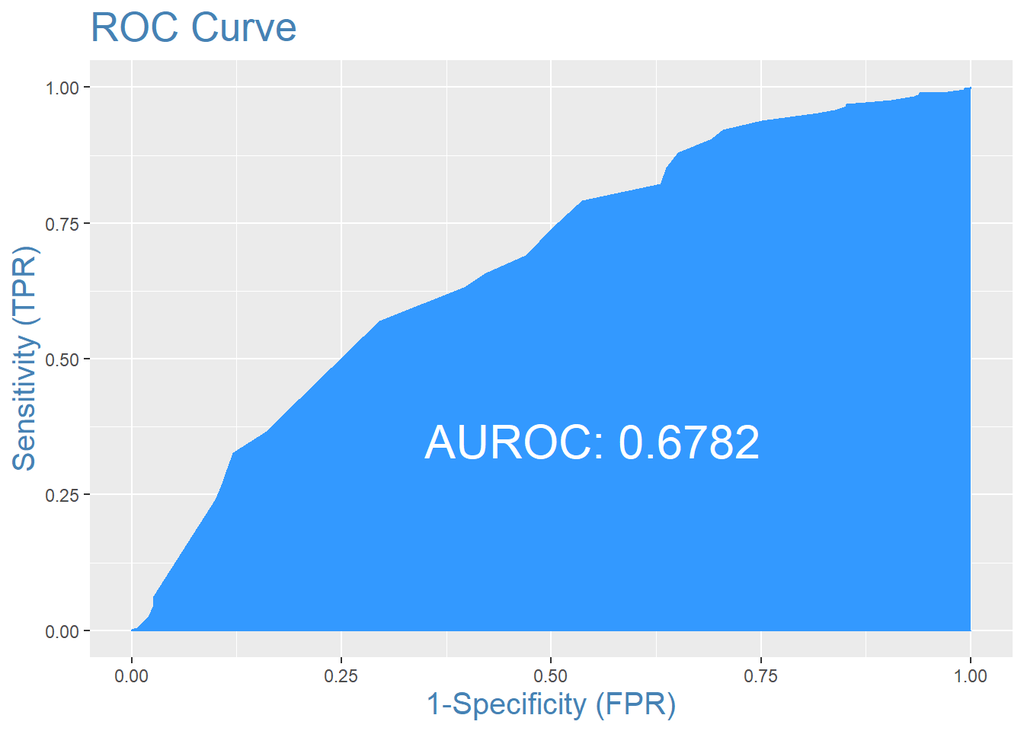

```r
plotROC(testingData$actual, predicted)
```